# Churn Analysis

Pik Shan Yiu

5/14/2019

```r
library(survival)
library(dplyr)
library(ggplot2)
library(scales)
library(reshape2)
library(ggcorrplot)
library(RColorBrewer)
library(randomForest)
library(caret)
```

```r
raw <- read.csv('Telco_churn.csv')
```

## Exploratory Data Analysis

A EDA will provide us with more insights and allow us to establish some hypothesis to test. Let’s take a quick look at the data first.

```r
str(raw)
```

```
## 'data.frame':    7043 obs. of  21 variables:
##  $ customerID      : Factor w/ 7043 levels "0002-ORFBO","0003-MKNFE",..: 5376 3963 2565 5536 6512 6552 1003 4771 5605 4535 ...
##  $ gender          : Factor w/ 2 levels "Female","Male": 1 2 2 2 1 1 2 1 1 2 ...
##  $ SeniorCitizen   : int  0 0 0 0 0 0 0 0 0 0 ...
##  $ Partner         : Factor w/ 2 levels "No","Yes": 2 1 1 1 1 1 1 1 2 1 ...
##  $ Dependents      : Factor w/ 2 levels "No","Yes": 1 1 1 1 1 1 2 1 1 2 ...
##  $ tenure          : int  1 34 2 45 2 8 22 10 28 62 ...
##  $ PhoneService    : Factor w/ 2 levels "No","Yes": 1 2 2 1 2 2 2 1 2 2 ...
##  $ MultipleLines   : Factor w/ 3 levels "No","No phone service",..: 2 1 1 2 1 3 3 2 3 1 ...
##  $ InternetService : Factor w/ 3 levels "DSL","Fiber optic",..: 1 1 1 1 2 2 2 1 2 1 ...
##  $ OnlineSecurity  : Factor w/ 3 levels "No","No internet service",..: 1 3 3 3 1 1 1 3 1 3 ...
##  $ OnlineBackup    : Factor w/ 3 levels "No","No internet service",..: 3 1 3 1 1 1 3 1 1 3 ...
##  $ DeviceProtection: Factor w/ 3 levels "No","No internet service",..: 1 3 1 3 1 3 1 1 3 1 ...
##  $ TechSupport     : Factor w/ 3 levels "No","No internet service",..: 1 1 1 3 1 1 1 1 3 1 ...
##  $ StreamingTV     : Factor w/ 3 levels "No","No internet service",..: 1 1 1 1 1 3 3 1 3 1 ...
##  $ StreamingMovies : Factor w/ 3 levels "No","No internet service",..: 1 1 1 1 1 3 1 1 3 1 ...
##  $ Contract        : Factor w/ 3 levels "Month-to-month",..: 1 2 1 2 1 1 1 1 1 2 ...
##  $ PaperlessBilling: Factor w/ 2 levels "No","Yes": 2 1 2 1 2 2 2 1 2 1 ...
##  $ PaymentMethod   : Factor w/ 4 levels "Bank transfer (automatic)",..: 3 4 4 1 3 3 2 4 3 1 ...
##  $ MonthlyCharges  : num  29.9 57 53.9 42.3 70.7 ...
##  $ TotalCharges    : num  29.9 1889.5 108.2 1840.8 151.7 ...
##  $ Churn           : Factor w/ 2 levels "No","Yes": 1 1 2 1 2 2 1 1 2 1 ...
```

```r
sapply(raw, function(x) sum(is.na(x)))
```

```
##       customerID           gender    SeniorCitizen          Partner
##                0                0                0                0
##       Dependents           tenure     PhoneService    MultipleLines
##                0                0                0                0
##  InternetService   OnlineSecurity     OnlineBackup DeviceProtection
##                0                0                0                0
##      TechSupport      StreamingTV  StreamingMovies         Contract
##                0                0                0                0
## PaperlessBilling    PaymentMethod   MonthlyCharges     TotalCharges
##                0                0                0               11
##            Churn
##                0
```

```r
raw[is.na(raw$TotalCharges), ]
```

```
##      customerID gender SeniorCitizen Partner Dependents tenure
## 489  4472-LVYGI Female             0     Yes        Yes      0
## 754  3115-CZMZD   Male             0      No        Yes      0
## 937  5709-LVOEQ Female             0     Yes        Yes      0
## 1083 4367-NUYAO   Male             0     Yes        Yes      0
## 1341 1371-DWPAZ Female             0     Yes        Yes      0
## 3332 7644-OMVMY   Male             0     Yes        Yes      0
## 3827 3213-VVOLG   Male             0     Yes        Yes      0
## 4381 2520-SGTTA Female             0     Yes        Yes      0
## 5219 2923-ARZLG   Male             0     Yes        Yes      0
## 6671 4075-WKNIU Female             0     Yes        Yes      0
## 6755 2775-SEFEE   Male             0      No        Yes      0
##      PhoneService    MultipleLines InternetService      OnlineSecurity
## 489            No No phone service             DSL                 Yes
## 754           Yes               No              No No internet service
```

[output cut: 45 more lines]

The quick scan of data shows that there are 11 missing values in column `TotalCharges`. An examination of these data report 0 in their tenure, suggesting that these are new customers who have not contributed revenues to the company yet. We can impute these missing values with 0 for now.

```r
raw$TotalCharges[is.na(raw$TotalCharges)] <- 0
```

Next, let’s look at the distrbution of churned customers across different profiles.

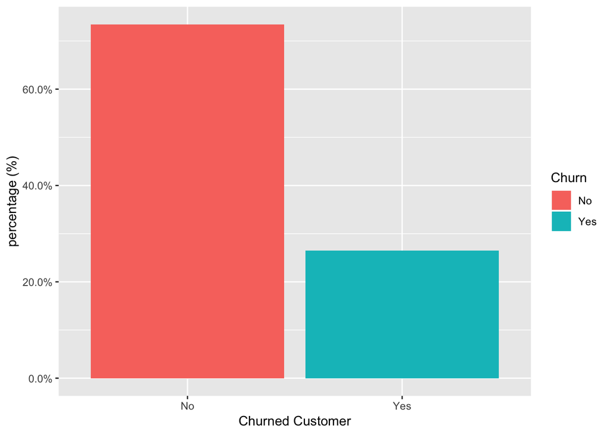

Nearly 30% of existing customers churned. Who are those who churned?

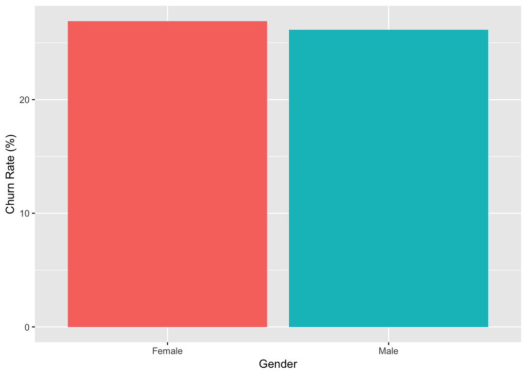

No obvious gender difference in churn rate.

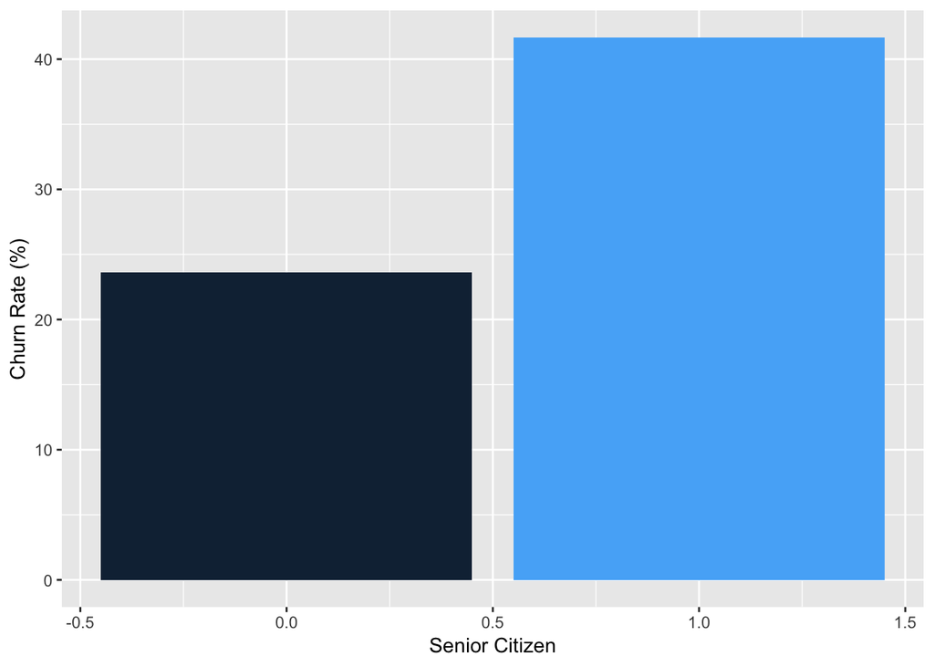

It sure is reasonable that senior citizen are more likely to churn, as they age they will naturally opt out of service.

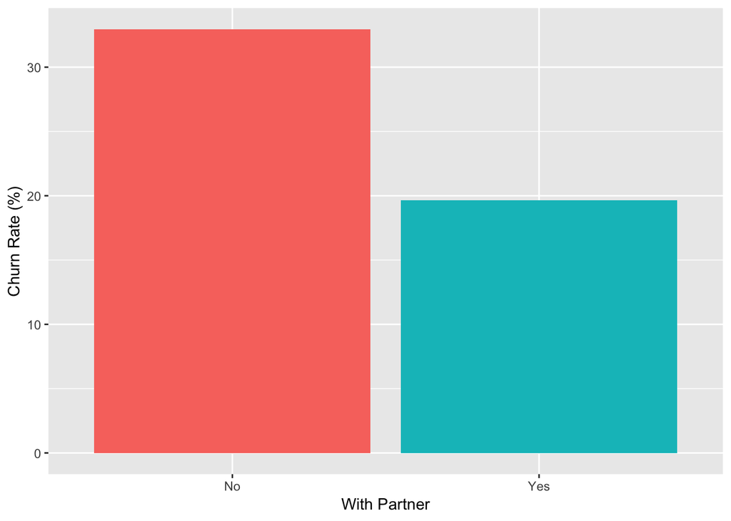

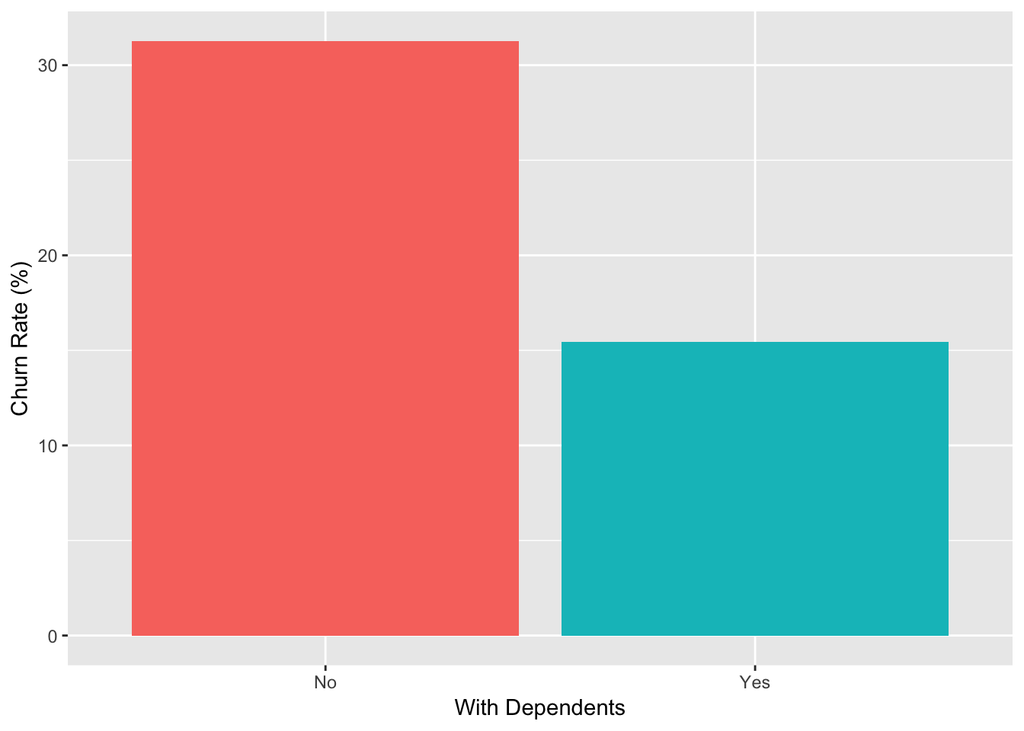

People with partners and dependents are less likely to churn.

How about different services?

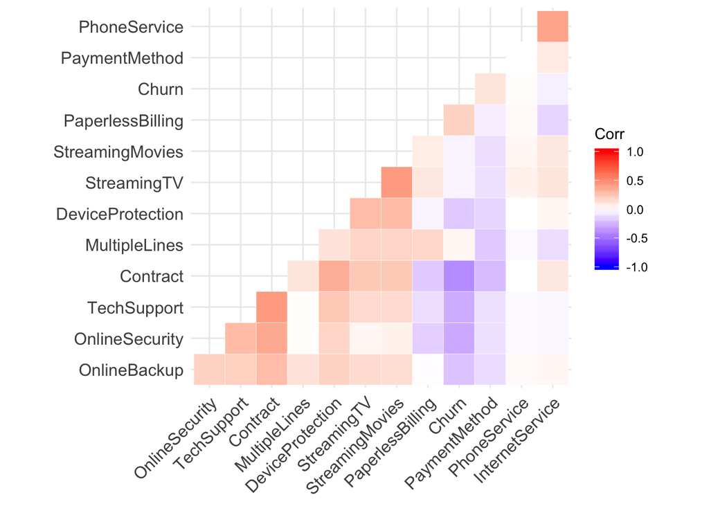

The correlation map shows that most extra services are correlated with lower churn, except for *paperpless billing*. In addition, longer the *contract*, shorter the churn rate. *Automatic payment* also makes customer less likely to churn. It is also worth checking if the paperless system is properly set up, or includes any inconvenient barriers.

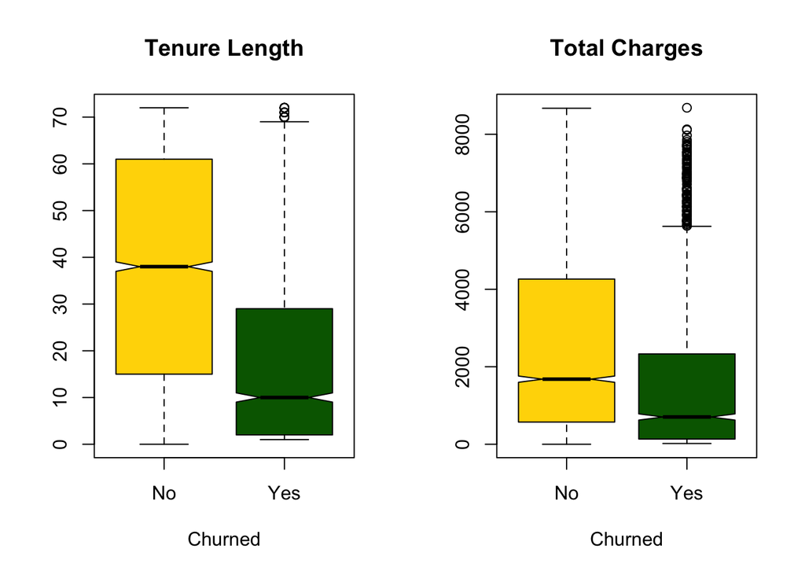

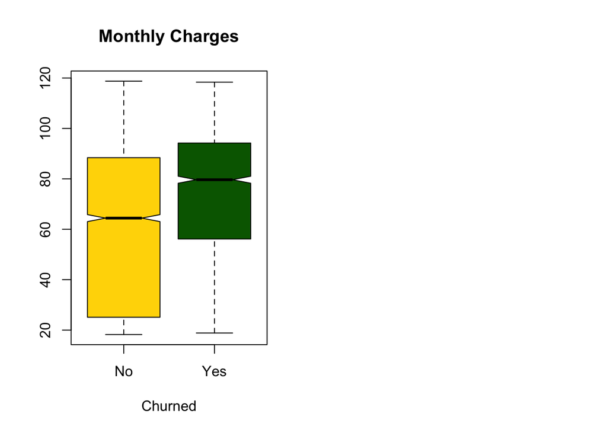

Overall, people are less likely to churn if they are in longer tenure and paid more in total service (naturally). What’s interesting, however, is the lower range of monthly charges for people who are less likely to churn, as shown in the third graph. It is hard to say for now what contributes to this difference. One possibility is that customer who enroll in month-to-month contract might pay a higher rate than those who are in longer contract, and they are more likely to churn. Let’s explore this hypothesis now.

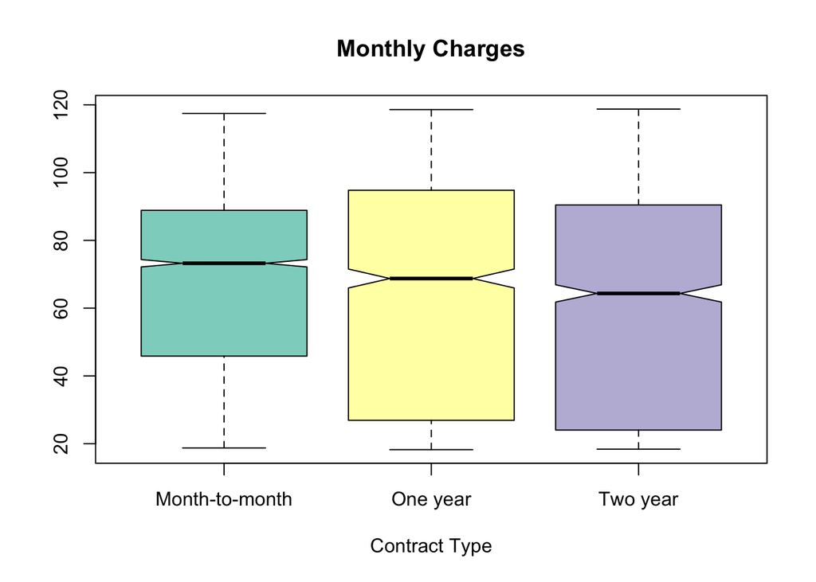

The graph confirms our hypothesis. Monthly contract is associated to higher monthly payment, hence related to higher churn possibility.

## Feature Importance and Churn Prediction

We can run models to understand what are the important factors that predict customers’ churn decisions, and verify with multiple models with the prediction. We can run a random forest model to take a look at feature importance.

```r
feat_subset <- raw[, -1]
set.seed(0715)
in_train <- createDataPartition(feat_subset$Churn, p = 0.8, list = FALSE)
training <-  feat_subset[in_train, ]
testing <- feat_subset[-in_train,]
```